# act_report

Background: The analysis that this report refers to is based on analysis done on tweets done by Twitter user WeRateDogs. WeRateDogs is a twitter account that rates people’s dogs with a humours comment about each dog.

Once the data was gathered, assessed, and cleaned, I was interested in seeing what, if any, interesting insights could be extracted from the dataset.

```python
import pandas as pd
import numpy as np
import seaborn as sns
import matplotlib.pyplot as plt

%matplotlib inline
```

```python
# Load cleaned DataFrame
df = pd.read_csv('twitter_archive_master.csv')
```

```python
# Reconvert the datatypes of the id columns and timestamp columns
df[['tweet_id', 'in_reply_to_status_id','in_reply_to_user_id']] = df[['tweet_id', 'in_reply_to_status_id','in_reply_to_user_id']].astype(str)
df.timestamp = pd.to_datetime(df.timestamp)
```

From the assesment done in the DataFrame, I know that all tweets in the data set aren't necessarily about dogs... I was interested in isolating the tweets that were about dogs for my analysis.

The first thing that I wanted to know was what percentage of the tweets were actually about dogs, which I found to be about 74%. Considering only the tweets that were about dogs, I was interested in seeing what were the most common dog breeds tweets were about and what their average ratings were.

#### What percantage of tweets are actually about dogs?

```python
len(df.query('p1_dog == True'))/len(df)
```

```
0.7407221664994985
```

#### What are the 10 most common dogs mentioned and what are their average ratings?

```python
common_dogs = list(df_dogs.p1.value_counts().head(10).index)
```

```python
common_dogs
```

```
['Golden_retriever',
 'Labrador_retriever',
 'Pembroke',
 'Chihuahua',
 'Pug',
 'Chow',
 'Samoyed',
 'Toy_poodle',
 'Pomeranian',
 'Malamute']
```

```python
df_dogs.p1.value_counts().head(10)
```

```
Golden_retriever      139
Labrador_retriever     95
Pembroke               88
Chihuahua              79
Pug                    54
Chow                   41
Samoyed                40
Toy_poodle             38
Pomeranian             38
Malamute               29
Name: p1, dtype: int64
```

```python
common_dogs_ratings = [df_dogs[df_dogs['p1'] == i]['overall_rating'].mean() for i in common_dogs]
```

```python
common_dogs_ratings
```

```
[1.1755162104082957,
 1.1126315789473682,
 1.1322727272727273,
 1.0708860759493675,
 1.024074074074074,
 1.1609756097560981,
 1.1700000000000004,
 1.110526315789474,
 1.1151315789473688,
 1.089655172413793]
```

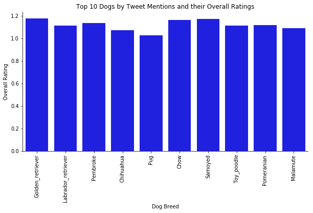

```python
# Plot the top ten dog breeds by their tweet mentions and include their overall ratings
fig, axes = plt.subplots(figsize = (10,5))
sns.barplot(x = common_dogs, y = common_dogs_ratings, color = 'Blue', orient = 'v', axes = axes)
plt.xticks(rotation=90)
axes.set_title('Top 10 Dogs by Tweet Mentions and their Overall Ratings')
axes.set_xlabel('Dog Breed')
axes.set_ylabel('Overall Rating')
sns.despine()
```

#### Is the popularity of a WeRateDog tweet affected by the month/ year it was tweeted?

```python
# Extract the tweet month and year from the tweet timestamp
df['tweet_month'] = df['timestamp'].dt.month
df['tweet_year'] = df['timestamp'].dt.year
```

```python
df.tweet_year.value_counts()
```

```
2016    974
2015    663
2017    357
Name: tweet_year, dtype: int64
```

Next, I was curious to know how/if favorites or retweets of WeRateDogs tweets were affected by the month that the tweets were tweeted. There seems to be the same general pattern in that from March till about June, WeRateDogs experiences an increase in the number of favorites and retweets of his tweets. There is, however, a noticeable sharp decline in the number of retweets and favorites between August and November but when you look at the data separated by year, we learn that the reason for this is because only 2016 has favorite/retweet data for a full calendar year.

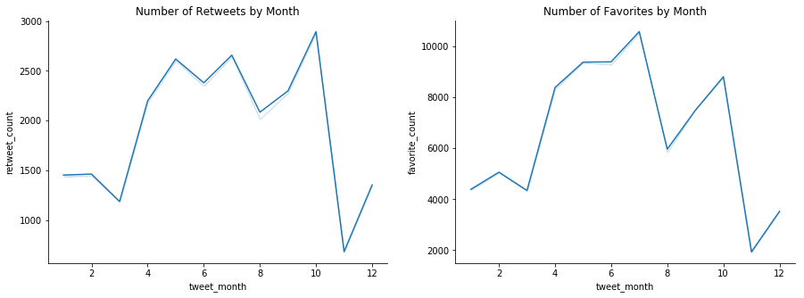

```python
#Plot tweet favorites and tweet retweets by month

fig, axes = plt.subplots(nrows = 1, ncols = 2, figsize=(15,5))

sns.set_palette("Blues_d")
sns.lineplot(x = 'tweet_month', y = 'retweet_count', data = df, ci = False, ax = axes[0]);
axes[0].set_title('Number of Retweets by Month')
sns.despine()

sns.lineplot(x = 'tweet_month', y = 'favorite_count', data = df, ci = False, ax = axes[1]);
axes[1].set_title('Number of Favorites by Month');
sns.despine()
```

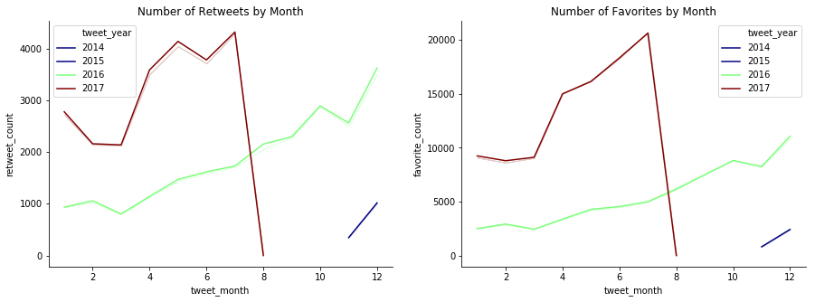

```python
# Plot tweet favorites and tweet retweets by month and year

fig, axes = plt.subplots(nrows = 1, ncols = 2, figsize=(15,5))

sns.set_palette("Blues_d")
sns.lineplot(x = 'tweet_month', y = 'retweet_count', data = df, ci = False, ax = axes[0], hue = 'tweet_year', palette= 'jet');
axes[0].set_title('Number of Retweets by Month')


sns.lineplot(x = 'tweet_month', y = 'favorite_count', data = df, ci = False, ax = axes[1], hue = 'tweet_year', palette= 'jet');
axes[1].set_title('Number of Favorites by Month');
sns.despine()
```

#### What is the relationship between favorites and retweets?

Lastly, I was interested in seeing the relationship between favorites and retweets of WeRateDogs tweets. As I suspected, there appears to be a strong positive correlation between favorites and retweets. What’s pretty cool to see though, I how the popularity of WeRateDogs tweets changes as the years go by (as evidenced by the number of favorites and retweets being increasing for each year).

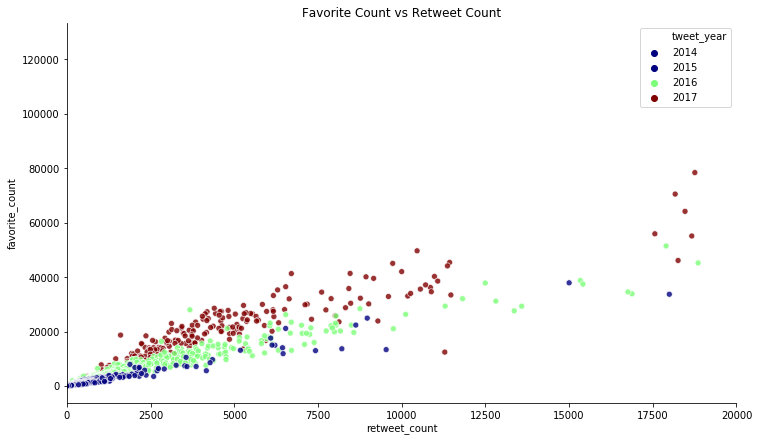

```python
# Plot retweets vs favorite count, separated by year
fig, axes = plt.subplots(figsize=(12,7))

sns.scatterplot(x = 'retweet_count', y = 'favorite_count', data = df, hue = 'tweet_year', alpha = .8, palette = 'jet', axes = axes)
axes.set_title('Favorite Count vs Retweet Count')
axes.set_xlim([0,20000])
sns.despine()
```